# Predicting Stocks

- [Home](http://michael-harmon.com)
- [Blog](http://michael-harmon.com/blog/index.html)
- [LinkedIn](https://linkedin.com/in/michaeldavidharmon)
- [GitHub](https://github.com/mdh266/)

# Predicting Stock Prices

## Contents

**1. Introduction**

**2. Classes**

**3. Modeling & Analysis**

**4. Conclusion**

The source code for this project can be found [here](https://github.com/mdh266/PredictingStocks).

## Introduction

In this project I wanted to look how to well we can predict the return on Goodyear (GT) stock based off of the return on other companies stock. The predictors I used were the return on the S&P 500 (SPY), Consumer Discretionary Select Sector (XLY), Ford (F), Toyota (T), and the exponentially weighted average of return on Ford and Toyota.

### Data

I used [Yahoo Finance](https://finance.yahoo.com/) as the source for data, since it makes historical stock data freely available. I chose 16 years worth of data and the common starting date of Aug. 1st 2000. Yahoo Finance provides the data to be downloaded in csv form. The data I used can be found in the "csv_files" directory.

I'll get into the modeling I choose to use later. The general libraries that I needed I import below:

```python
import pandas as pd
import numpy as np
from sklearn import linear_model
from sklearn import metrics
from sklearn.cross_validation import cross_val_score
from sklearn.cross_validation import train_test_split
from sklearn import preprocessing
import seaborn as sns
import matplotlib.pyplot as plt
%matplotlib inline
```

I decided to make classes for some of the tools in the analysis to get used to objected oriented programming in Python, though it is definitely overkill for such a small project.

## Classes

### stock_data class

The first class, stock_data, creates the pandas dataframe that will contain all the predictor stocks as well as the target stock values. The constructor will read in the raw data from the csv files and clean it. By cleaning, I mean it will lag the predictors/features so that they are a day behind the target. This elimates any ability of the model to "peak into the future." It also creates the predictors/features that are the exponentially weighted average of the stocks. The objects stores all these features and the target values into the pandas dataframe called "df."

The only other method in the class stock_data is "scale" function which scales the data and stores the mean and std of each feature column. It was important for me to encapsulate these two functions into a object, since I wanted to able to rescale the predicted results once the modeling was complete. By having the mean and std of features columns stored in the same object as the dataframe this made this process of rescaling the predicted values easier.

### data_visualizer class

The data_visualizer class was just a container for different plotting mechanisms I would be using. While it is not necessary for such a small project, I wanted to maintain all the visualization methods into one object for future use in other projects.

```python
class stock_data(object):

    # feature/predictor stock symbols
    features = ['SPY','EMA(F)','EMA(T)','XLY','F','T']

    # targer stock symbols
    target = 'GT'

    def __init__(self):
        """
        This constructor will read and cleans the data
        from the csv files.  Lagging and creating the exp.
        weight mean features.

        - creates self.df
        """
        # DATA VARIABLES
        self.df = None
        self.mean = None
        self.std = None


        # Read in the data from csv database
        data_F = pd.read_csv('csv_files/FORD.csv')
        data_T = pd.read_csv('csv_files/TOYOTA.csv')
        data_GT = pd.read_csv('csv_files/GOODYEAR.csv')
        data_SPY = pd.read_csv('csv_files/SPY.csv')
        data_XLY = pd.read_csv('csv_files/XLY.csv')

        # Lag the predictors compared to response so as to not
        # "peak into the future."

        # Drop the last day of predictors
        data_F.drop(data_F.index[0],inplace=True)
        data_T.drop(data_T.index[0],inplace=True)
        data_SPY.drop(data_SPY.index[0],inplace=True)
        data_XLY.drop(data_XLY.index[0],inplace=True)


        # Drop the first day of response
        last = data_GT.shape[0]-1
        data_GT.drop(data_GT.index[last],inplace=True)

        # Get the daily percent change i.e. daily return
        R_F = data_F['Adj Close'].pct_change()
        R_T = data_T['Adj Close'].pct_change()
        R_SPY = data_SPY['Adj Close'].pct_change()
        R_XLY = data_XLY['Adj Close'].pct_change()
        R_GT = data_GT['Adj Close'].pct_change()


        # Compute the exponentially weighted average of
        # Ford and Toyoya over prev_days days
        prev_days = 30
        R_F_EMA = pd.Series.ewm(R_F,span=prev_days).mean()
        R_T_EMA = pd.Series.ewm(R_T,span=prev_days).mean()


        # Now drop the first 50 days to remove NANs from EMA data
        R_F.drop(R_F.index[0:prev_days],inplace=True)
        R_T.drop(R_T.index[0:prev_days],inplace=True)
        R_SPY.drop(R_SPY.index[0:prev_days],inplace=True)
        R_XLY.drop(R_XLY.index[0:prev_days],inplace=True)
        R_GT.drop(R_GT.index[0:prev_days],inplace=True)
        R_F_EMA.drop(R_F_EMA.index[0:prev_days],inplace=True)
        R_T_EMA.drop(R_T_EMA.index[0:prev_days],inplace=True)


        # Create the database, removing the first and last row
        # since they are NANs
        self.df = pd.DataFrame({'SPY':R_SPY,
                                'EMA(F)':R_F_EMA,
                                'EMA(T)':R_T_EMA,
                                'XLY':R_XLY,
                                'F':R_F,
                                'T':R_T,
                                'GT':R_GT})



        # first and last row have NANs
        self.df.drop(self.df.index[0], inplace=True)
        self.df.drop(self.df.index[self.df.shape[0]-1], inplace=True)

        # check to see if any NANs left
        #print df.isnull().values.any()


    def scale(self):
        """Scale the data so that the mean and std of the columns are
        0 and 1 respectively."""
        # standardize the data
        self.mean = self.df.mean()
        self.std = self.df.std()

        self.df = (self.df - self.mean/self.std)
```

```python
class data_visualizer(object):
    ''' This class is just a container for different visualizations
    of the data stored in stock_dat object.'''

    def __init__(self):
        """Empty constructor."""

    def corr(self, data):
        """Makes a heatmap of the correlation matrix."""
        sns.heatmap(data.df.corr())

    def simple_least_squares(self, data):
        """Plots the simple least squares regression lines
        with confidence intervals for each of the features."""
        sns.pairplot(data.df, x_vars=data.features,
                     y_vars=data.target, kind='reg', size=8)
```

## Analysis

Lets first instantiate our stock_data and data_visualizer objects as well as scale the data.

```python
data = stock_data()
viz = data_visualizer()
data.scale()
```

We first get a taste for the data by looking at scatter plots of GT against each of its features and fit a linear regression model to each using the Seaborn pairplot function:

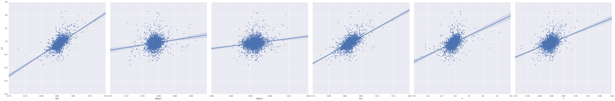

```python
viz.simple_least_squares(data)
```

Lets focus in on developing a simple linear regression model for GT stock returns from SPY returns.

We first get the data and plot the regression line for the data again as we did above, just so we can observe the relationship between the two stocks a little better.

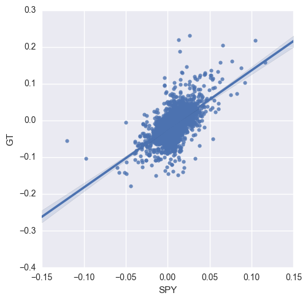

```python
SPY = pd.Series.to_frame(data.df['SPY'])
GT = pd.Series.to_frame(data.df['GT'])

# Plot regression line
sns.pairplot(data.df, x_vars='SPY',y_vars='GT',kind='reg',size=5)
```

Now to build a predictive model. We first split up our data into training and test sets, taking the test set as the last 1000 days

```python
# get the number of responses
N = SPY.shape[0]
# num_tests is number days used for test predictors
num_test = 1000

# use the latest num_test values of the returns as the test data
X_test = SPY.head(num_test)
X_train = SPY.tail(N-num_test)
Y_test = GT.head(num_test)
Y_train = GT.tail(N-num_test)
```

We then fit the model to the training data and compute the training mean square error by using 10 fold cross validation,

```python
reg = linear_model.LinearRegression()

MSE_scores = cross_val_score(reg,
                             X_train,
                             Y_train,
                             cv=10,
                             scoring="neg_mean_squared_error")

print "10-fold CV MSE = " + str(-MSE_scores.mean())
```

```
10-fold CV MSE = 0.000775262372388
```

The training MSE is pretty small, let's see if its close to the test error:

```python
reg.fit(X_train,Y_train)
Y_pred = reg.predict(X_test)

print "test mse = " + str(metrics.mean_squared_error(X_test, Y_pred))
```

```
test mse = 0.000385031004095
```

The test mean square error is about half of the training error, it seems we got pretty lucky! However, the mean square error isn't always the best measure of how our model is peforming. Let's instead look at the $R^2$ score; which is a statistic that measures the proportion of variance in data that our regression model can explain. We use 10 fold cross validation to estimate our training $R^2$ score:

```python
R_scores = cross_val_score(reg,
                           X_train,
                           Y_train, cv=10,
                           scoring="r2")

print "10-fold CV training R^2 score = " + str(R_scores.mean())
```

```
10-fold CV training R^2 score = 0.327986596532
```

Our model is not explaining much of the variance in the tranining data and we expect that the test $R^2$ score is only going to be lower.

Let's take a look at the relationship between features as well as with the target. We can look at the correlation between different features and the target using the heatmap utility (from the seaborn library) on the correlation matrix:

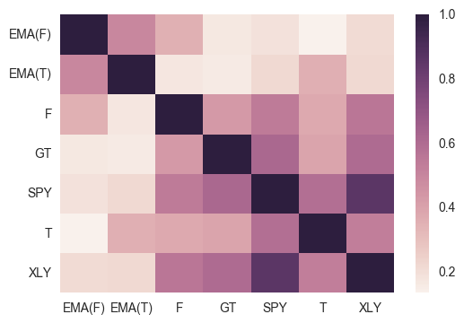

```python
viz.corr(data)
```

We can see that SPY and XLY are highly correlated. The exponential moving average of both Ford and Toyota seem to be correlated as well. GT is most correlated with SPY and XLY, then somewhat correlated with Ford and Toyta. Interstingly, GT is not very correlated with the exponential moving avarge of either car company.

We now peform multiple linear regression on all the features to see if we can improve the $R^2$ score. First we obtain the data in pandas dataframes:

```python
# first obtain the predictors and response
X = data.df[data.features]
Y = data.df[data.target]
```

We now break up the data into testing and training sets. We again take the test set to be the last 1000 days.

```python
# get the number of responses
N = Y.shape[0]

# num_tests is number days used for test predictors
num_test = 1000

# use the latest num_test values of the returns as the test data
X_test = X.head(num_test)
X_train = X.tail(N-num_test)
Y_test = Y.head(num_test)
Y_train = Y.tail(N-num_test)
```

We then instantiate a multiple linear regression model and find the training mean square error using 10 fold cross validation:

```python
reg = linear_model.LinearRegression()
MSE_scores = cross_val_score(reg,
                             X_train,
                             Y_train,
                             cv=10,
                             scoring="neg_mean_squared_error")

print "10-fold CV training MSE = " + str(-MSE_scores.mean())
```

```
10-fold CV training MSE = 0.00074469707527
```

The training error in the multiple linear regression model is about the same as in the simple linear regression model. We can now fit the model to the training data and see how it preforms on the test set.

```python
reg.fit(X_train, Y_train)
y_pred = reg.predict(X_test)
y_train_pred = reg.predict(X_train)

print 'test mse = ' + str(metrics.mean_squared_error(Y_test, y_pred))
```

```
test mse = 0.000269391772309
```

We can see that the test error is smaller using multiple linear regression compared to using a simple linear regression model. This makes sense since were only adding in information that is correlated to the target values. Let's see how well the new model explains the variance in the data:

```python
R_scores = cross_val_score(reg,
                           X_train,
                           Y_train, cv=10,
                           scoring="r2")

print "10-fold CV training R^2 score = " + str(R_scores.mean())
```

```
10-fold CV training R^2 score = 0.351700953091
```

Multiple linear regression over all explains about 2% more variance than simple linear regression. This is somewhat suprising, the extra features we added must not add much information.

Let's see how highly correlated the features are to the target by looking at the coefficient values:

```python
print 'coefficients:'
zip(data.features, reg.coef_)
```

```
coefficients:
```

```
[('SPY', 0.89111225733332811),
 ('EMA(F)', 0.06132913124484321),
 ('EMA(T)', -0.0025273300170375328),
 ('XLY', 0.56602331041433451),
 ('F', 0.10166289773382987),
 ('T', 0.058438407840357288)]
```

Overall SPY seems to have the most effect on GT, but XLY also has a strong effect. However, from the correlation matrix we can see that XLY and SPY are highly correlated.

There are different ways we can go about improving the peformance of our model, the one we will now look into is model selection using Lasso. We are not in danger of over-fitting the data since our training and test set errors are both small and were not doing too great a job of explaining the variance in the data.

We now train the Lasso model using 10 fold cross validation to find the optimal tuning perameter

```python
reg = linear_model.LassoCV(cv=10).fit(X_train,Y_train)
```

We can plot the errors for different penalty parameter values for each of the cross validation sets

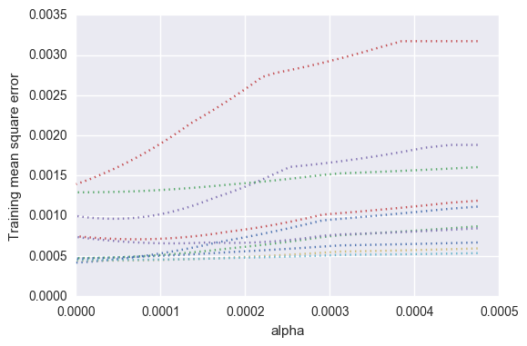

```python
plt.plot(reg.alphas_, reg.mse_path_, ':')
plt.xlabel('alpha')
plt.ylabel('Training mean square error')
```

The optimal tunning parameter can then be found by typing:

```python
print 'optimal penalty parameter = ' + str(reg.alpha_)
```

```
optimal penalty parameter = 8.89381021877e-07
```

This is a pretty small penalty value so we dont expect much variable selection or improvement in our model peformance. We can see the test set mean square error is about the same as that produced using multiple linear regression,

```python
y_pred = reg.predict(X_test)
test_mse = metrics.mean_squared_error(Y_test, y_pred)
print 'test mse = ' + str(test_mse)
```

```
test mse = 0.000269259592602
```

We can see that not much in the way has been done with feature selection either:

```python
print "Optimal alpha's coefficients:"
zip(data.features, reg.coef_)
```

```
Optimal alpha's coefficients:
```

```
[('SPY', 0.88667663637724015),
 ('EMA(F)', 0.036652240053239506),
 ('EMA(T)', 0.0),
 ('XLY', 0.56614060342053385),
 ('F', 0.10372024377007137),
 ('T', 0.057352023722663265)]
```

And not suprisingly the $R^2$ score for Lasso is about the same as for multiple linear regression

```python
R_scores = cross_val_score(reg,
                           X_train,
                           Y_train, cv=10,
                           scoring="r2")

print "10-fold CV training R^2 score = " + str(R_scores.mean())
```

[output not shown]

## Conclusion

Overall linear modeling using multiple linear regression is not a great model for predicing returns on Goodyear tires from knowledge of the selected predictor companies. Linear regression without regularization and with $L_1$ regularization (Lasso) perform about equally well. Overall they able to explain about 35% of the variance in the training set data and percentage of variance explained on the test set data is expected to be even smaller. More complicated models should be considered and adding in addational features is also necessarry to improve the predictive power.